# Exemplos de códigos com a PNAD e LinkedIn

Marcelo Ventura

## Descrição

Exemplos de códigos com dados da PNAD de: Acesso à Internet e posse de telefone móvel celular para uso pessoal 2001(Domicílios); 2015 (Pessoas)

## Interpretando o documento

Os 4 primeiros caracteres são anos de referência.

Os dois seguintes são unidade da federação.

Os 8 seguintes são os números de controle.

Os 3 seguintes são os números de série.

Por assim vai, há um dicionário para domicílios e pessoas.

```r
tabelateste <- read.table("~/Onedrive/github/PNAD/dados/DOM2001.TXT",sep="\t") #extraindo arquivo
tabela <- as.data.frame(cbind(substr(tabelateste$V1,1,4),substr(tabelateste$V1,5,6),
                substr(tabelateste$V1,7,14),substr(tabelateste$V1,15,17),
                substr(tabelateste$V1,23,23),substr(tabelateste$V1,30,30),
                substr(tabelateste$V1,147,158)))%>%
  `colnames<-`(c("Ano","UF","Controle","Serie", "Tipo.dom","Situacao","Renda.dom")) #montando tabela vide dicionario de variaveis para domicilios
tabela <- tabela[complete.cases(tabela),]#removendo linhas com NA
tabela$UF.extensa <- tabela$UF%>%
          gsub("11","Rondonia",.)%>%gsub("12","Acre",.)%>%gsub("13","Amazonas",.)%>%
          gsub("14","Roraima",.)%>%gsub("15","Para",.)%>%gsub("16","Amapa",.)%>%
          gsub("17","Tocantins",.)%>%gsub("21","Maranhao",.)%>%gsub("22","Piaui",.)%>%
          gsub("23","Ceara",.)%>%gsub("24","Rio Grande do Norte",.)%>%gsub("25","Paraiba",.)%>%
          gsub("26","Pernambuco",.)%>%gsub("27","Alagoas",.)%>%gsub("28","Sergipe",.)%>%
          gsub("29","Bahia",.)%>%gsub("31","Minas Gerais",.)%>%gsub("32","Espirito Santo",.)%>%
          gsub("33","Rio de Janeiro",.)%>%gsub("35","Sao Paulo",.)%>%gsub("41","Parana",.)%>%
          gsub("42","Santa Catarina",.)%>%gsub("43","Rio Grande do Sul",.)%>%gsub("50","Mato Grosso do Sul",.)%>%
          gsub("51","Mato Grosso",.)%>%gsub("52","Goias",.)%>%gsub("53","Distrito Federal",.)#modificando os objetos vide o estado
tabela$Tipo.dom%<>%
  gsub("2","Casa",.)%>%gsub("4","Apartamento",.)%>%gsub("6","comodo",.)%>%gsub("9","Ignorado",.)%>%
  gsub(" ", "Nao aplicavel",.)#modificando os objetos vide o tipo de domicilio
tabela$Situacao %<>% gsub(" ", "Nao aplicavel",.)%>%gsub("1","Proprio pago",.)%>%gsub("2","Proprio pagando",.)%>%
  gsub("3","Alugado",.)%>%gsub("4","Cedido por empregador",.)%>%
  gsub("5","Cedido de outra forma",.)%>%gsub("6","Outra condição",.)%>%gsub("9","Ignorado",.)#modificando os objetos vide a situação do imóvel
tabela$Renda.dom%<>%as.character(.)%>%
  gsub(" ","Nao aplicavel",.)%>%
  gsub("999999999999","Ignorado",.)%>%#modificando os objetos vide a situacao do imovel
  as.numeric(.)
```

## Parte 1) O pacote ggplot2

O gráfico abaixo gera uma plotagem para as mil primeiras observações, onde UF é igual ao estado em questão, e tipo de domicílio é se a entrevista foi realizada em apartamento, casa, etc.

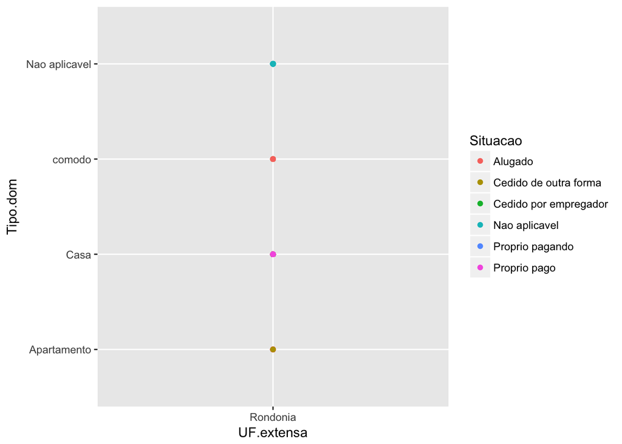

```r
ggplot(data=tabela[1:1000,])+geom_point(mapping=aes(x=UF.extensa,y=Tipo.dom,color=Situacao))
```

Acima podemos verificar que existem 4 tipos para a amostra das primeiras mil observações retirada da base, as quais consideraram apenas o estado de Rondonia.

No entanto, seria mais interessante saber em um gráfico de pontos qual a frequencia de cada tipo de moradia, ou a relação entre duas variáveis. Considerando a variável de situação do domicílio. Por exemplo, poderemos saber se ele é pago, alugado, cedido, qual a situação do pagamento…

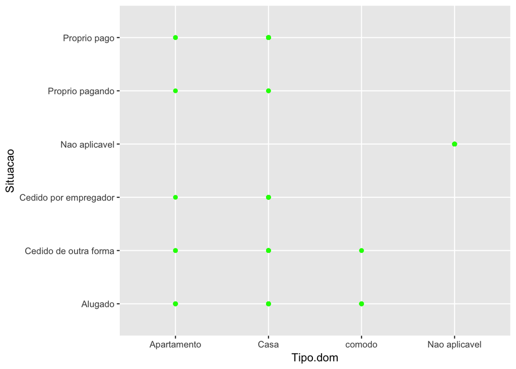

```r
ggplot(data=tabela[1:1000,])+geom_point(mapping=aes(x=Tipo.dom,y=Situacao),color="green")
```

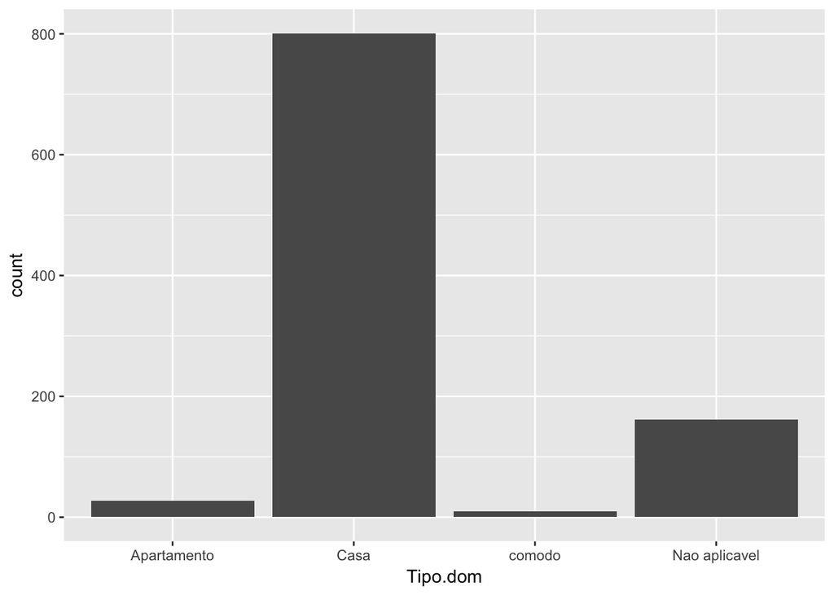

```r
ggplot(data=tabela[1:1000,])+geom_bar(mapping=aes(x=Tipo.dom))
```

Com o gráfico acima verificamos que para a amostra das primeiras 1000 observações, a casa é predominante na base de dados. Mas e para todos os dados?

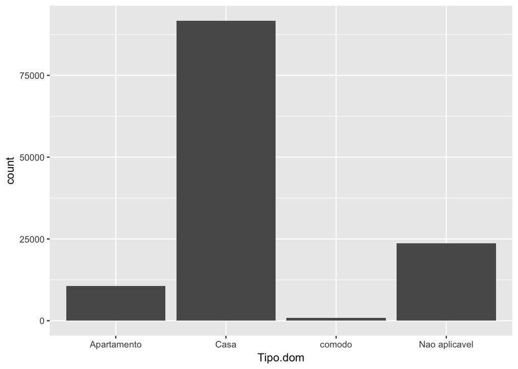

```r
ggplot(data=tabela)+geom_bar(mapping=aes(x=Tipo.dom))
```

Em 2001 a PNAD foi coletada em um número expressivo de casas. No entanto, como é a relação desse tipo de domicílio com o seu estado? Ela é própria, alugada?

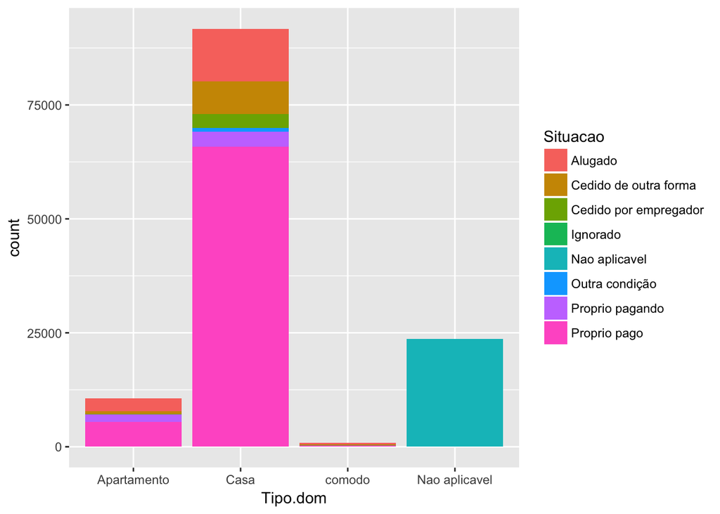

```r
ggplot(data=tabela)+geom_bar(mapping=aes(x=Tipo.dom,fill=Situacao))
```

Ou seja, acima temos 3 histogramas, desenvolvidos com mais camadas por cada pergunta que quisemos responder.

Agora, se quisermos ver por cada estado, qual o tipo de propriedade em cada um, e qual a situação em que ele se encontra?

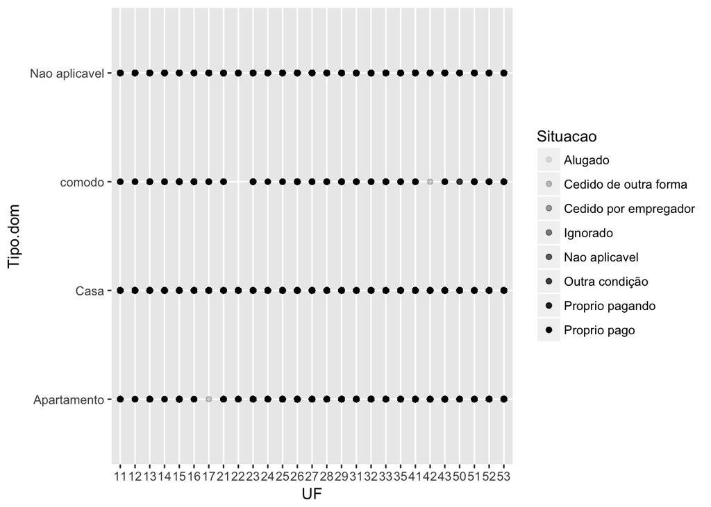

```r
ggplot(data=tabela)+geom_point(mapping=aes(x=UF,y=Tipo.dom,alpha=Situacao))
```

Horrível, não? Note que o alpha acima classifica a situação com a transparência dos pontos. Aplicando shape ao invés de alpha deixaria o gráfico dessa forma:

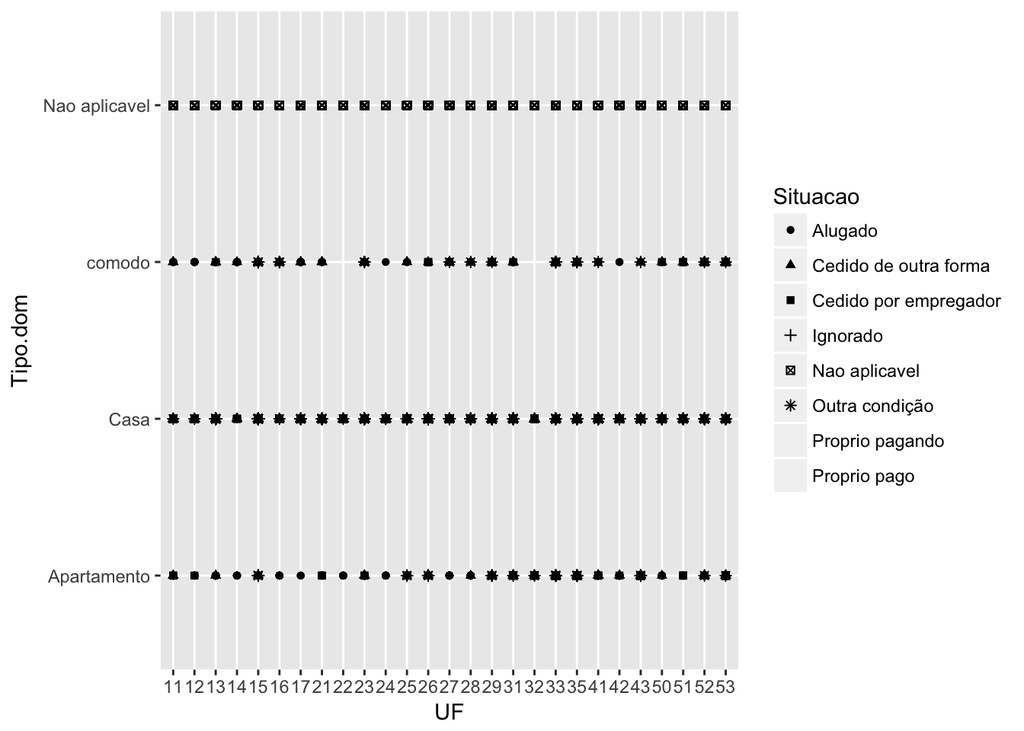

```r
ggplot(data=tabela)+geom_point(mapping=aes(x=UF,y=Tipo.dom,shape=Situacao))
```

Ainda assim fica um gráfico pouco legível….pois o comando shape utiliza seis elementos somente.

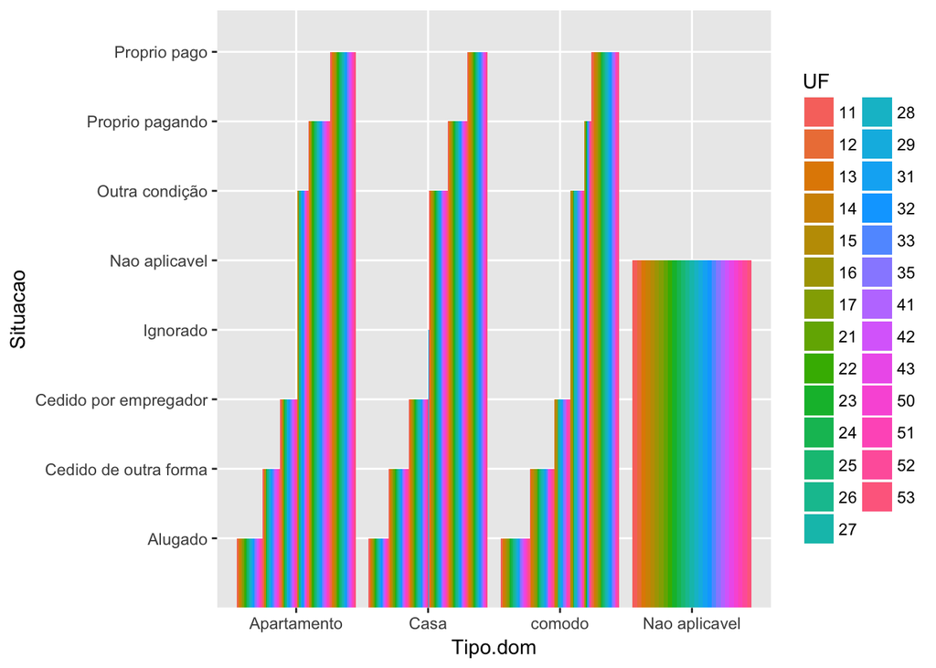

```r
ggplot(data=tabela,aes(x=Tipo.dom,y=Situacao,fill=UF))+geom_bar(stat="identity", position=position_dodge())
```

Uma coisa importante a se saber é que dentro do aes() vão os elementos estéticos, geralmente o objeto do eixo x, e y. Fora do aes() vao os elementos que não dependem das variáveis, como cor, tamanho do ponto, etc.

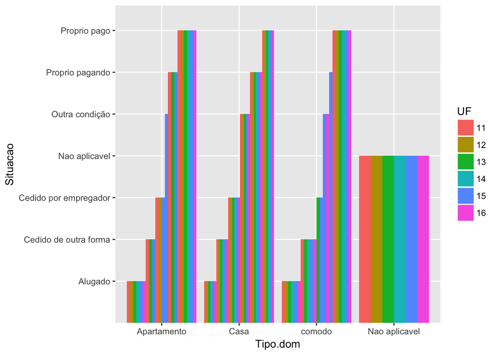

```r
ggplot(data=tabela[1:10000,],aes(x=Tipo.dom,y=Situacao,fill=UF))+geom_bar(stat="identity", position=position_dodge())
```

Reduzindo o número de estados até que a visualização melhora um pouco. Nesse caso caberia deixar o estado como eixo x.

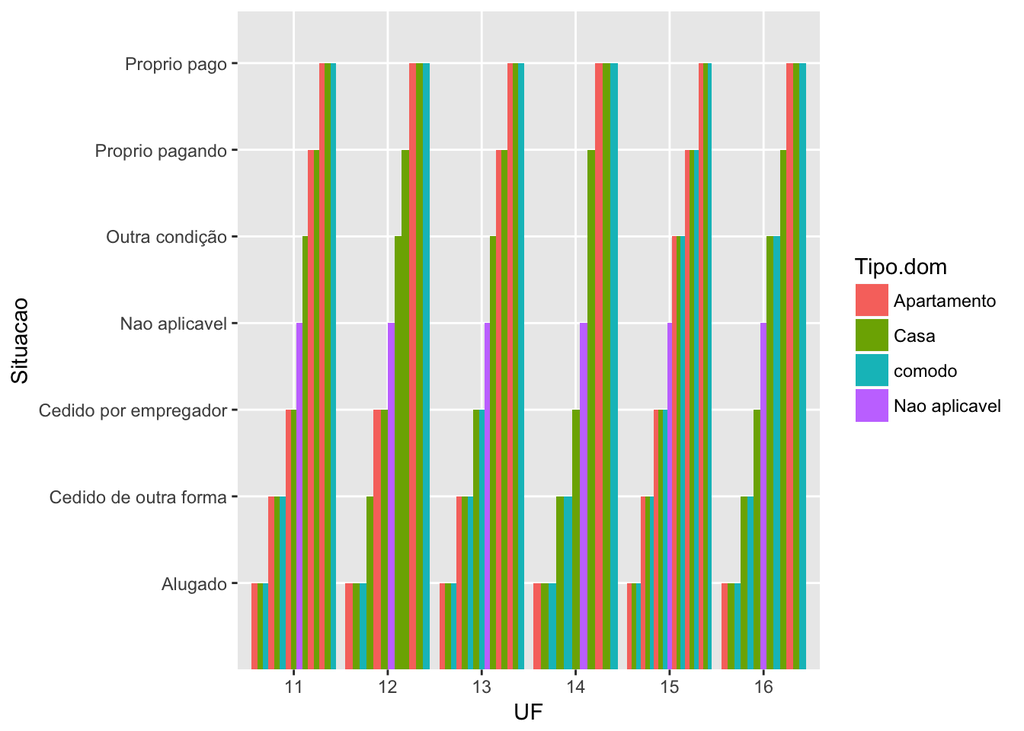

```r
ggplot(data=tabela[1:10000,],aes(x=UF,y=Situacao,fill=Tipo.dom))+geom_bar(stat="identity", position=position_dodge())
```

Mudando o elemento de posicao dodge para fill, teremos:

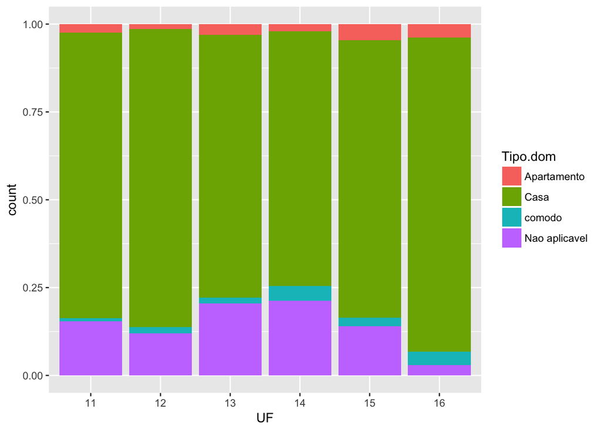

```r
ggplot(data=tabela[1:10000,])+geom_bar(mapping=aes(x=UF,fill=Tipo.dom), position="fill")
```

O comando facet_wrap permite gerar vários gráficos, logo, podemos gerar para as 10000 primeiras amostras gráficos por estado. Vejamos:

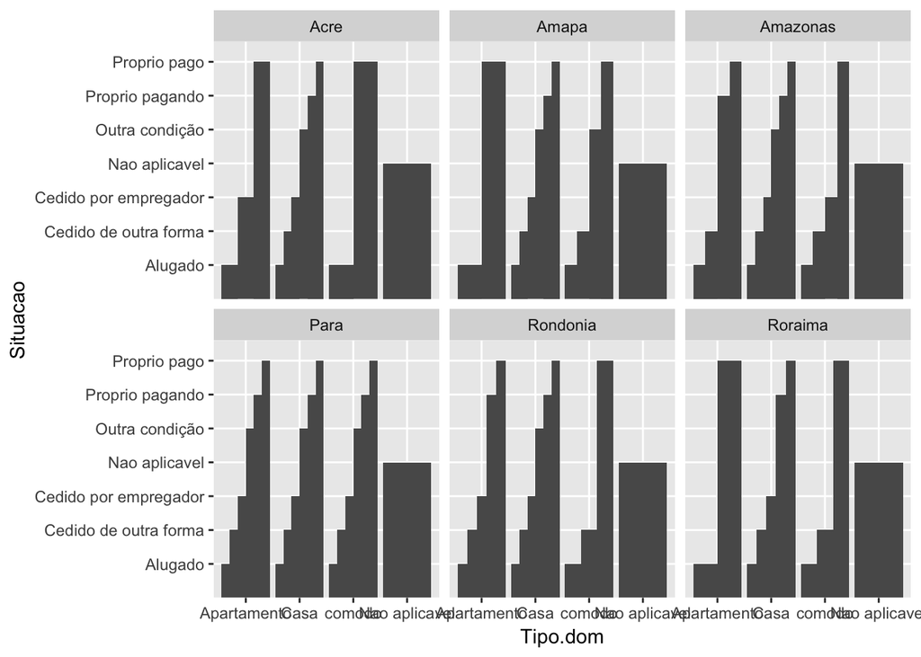

```r
ggplot(data=tabela[1:10000,],aes(x=Tipo.dom,y=Situacao))+geom_bar(stat="identity", position=position_dodge())+facet_wrap(~UF.extensa,nrow=2)
```

Agora ficou show! Tentando fazer para todos os estados teremos:

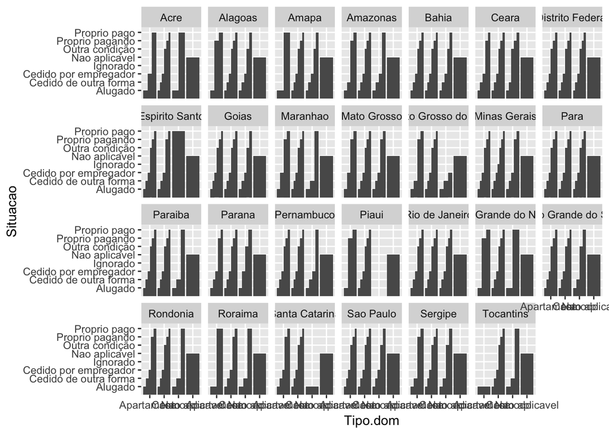

```r
ggplot(data=tabela,aes(x=Tipo.dom,y=Situacao))+geom_bar(stat="identity", position=position_dodge())+facet_wrap(~UF.extensa,nrow=4)
```

Outro tipo de facet é o facet_grid, que separa o gráfico em combinações de duas variáveis. Por exemplo:

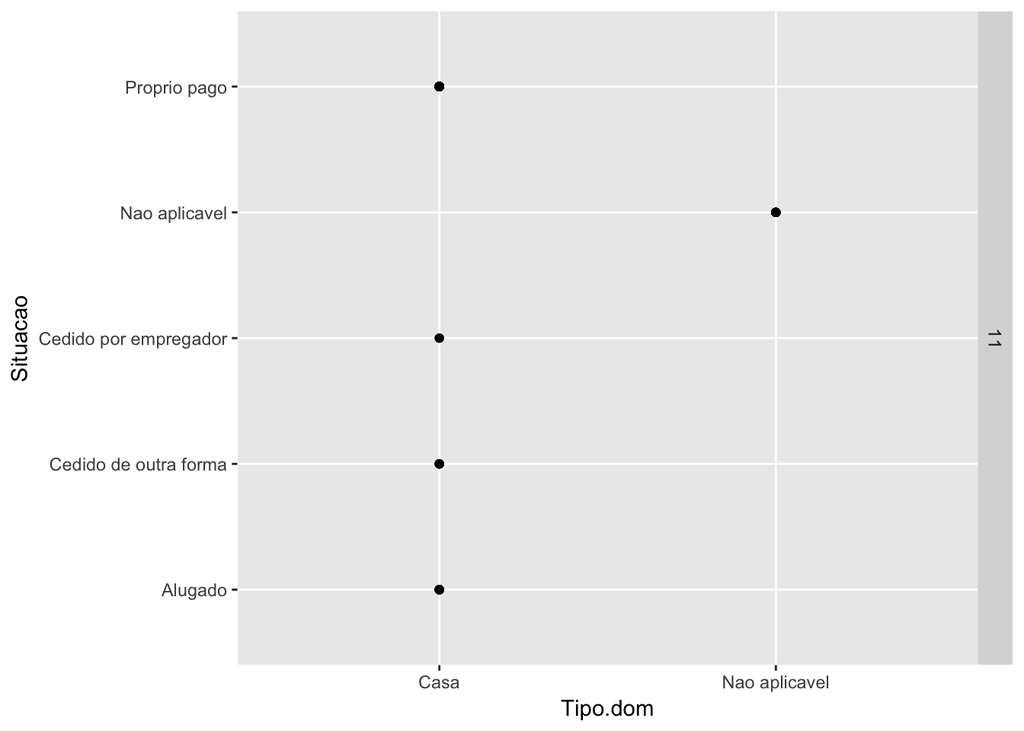

```r
ggplot(data=tabela[1:100,],aes(x=Tipo.dom,y=Situacao))+geom_point()+facet_grid(UF~.)
```

Agora começaremos as análises analisando a renda domiciliar.

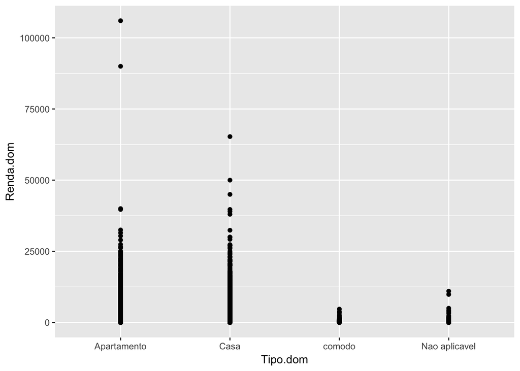

```r
ggplot(data=tabela) + geom_point(aes(x=Tipo.dom, y=Renda.dom))
```

Só com o gráfico acima podemos perceber que a renda domiciliar é maior para apartamentos e casas, onde o valor máximo nos apartamentos ultrapassa 75000 reais para 2 entrevistas.

E se colocarmos x=UF?

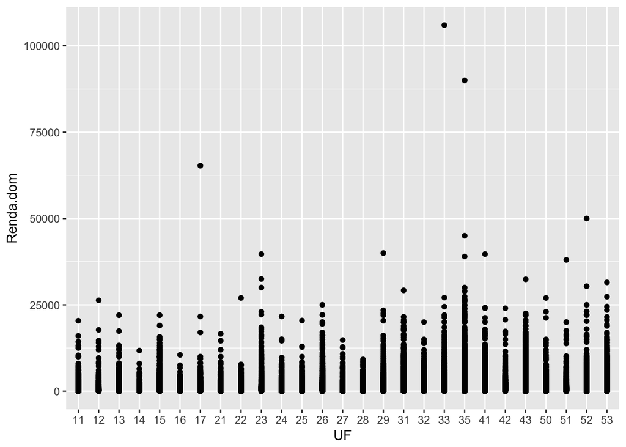

```r
ggplot(data=tabela) + geom_point(aes(x=UF, y=Renda.dom))
```

Considerando as regioes Norte (11-17), Nordeste(21-29), Sudeste(31-35), Sul(41-43), Centro-Oeste(50-53), vemos que 33(Rio de Janeiro), 35(Sao Paulo), 17(Tocantins), 52(Goiás) foram os estados com maiores limites de renda máxima.

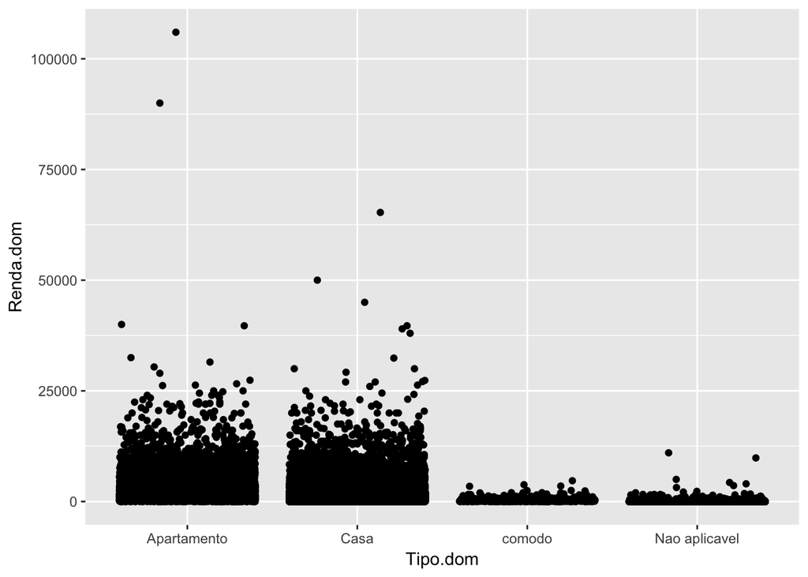

```r
ggplot(data=tabela)+geom_point(mapping=aes(x=Tipo.dom,y=Renda.dom),position="jitter")
```

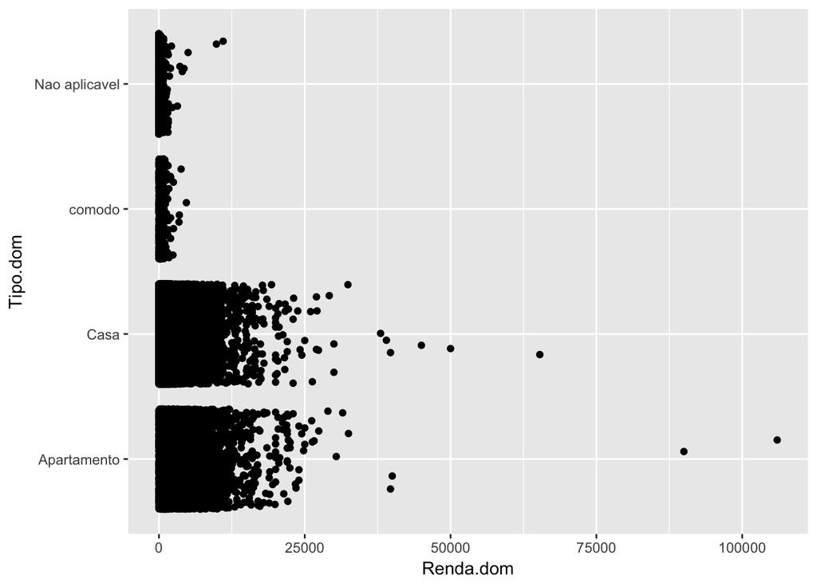

```r
ggplot(data=tabela)+geom_point(mapping=aes(x=Tipo.dom,y=Renda.dom),position="jitter")+coord_flip()
```

## Parte 2) Usando o pacote dplyr

filter():escolha observacoes por seus valores arrange():reordene as linhas select():pegue variaveis com seus nomes mutate():crie novas variaveis com funçoes para variaveis existentes summarize():traga varios valores para o resumo

Filtrando estados diferentes

filter(tabela,UF==“11”)#filtrando estados de Rondonia filter(tabela,Renda.dom<1000)#Filtrando renda domiciliar menor que 1000 reais

filter(tabela,UF==“11”&Renda.dom>1000)#Filtrando Rondonia e renda domiciliar maior que 1000

filter(tabela,UF %in% c(11,31)&Renda.dom>2000) #filtrando em rondonia e em minas rendas domiciliares maiores que 2000 reais

Trabalhando com missings.

is.na()

Exemplo, verificando se alguma observação da tabela está faltando na coluna UF.

filter(tabela, is.na(UF))

A resposta é não. Mas e para a coluna Renda.dom?

filter(tabela, is.na(Renda.dom))

Existem várias. Mas quantas?

nrow(filter(tabela, is.na(Renda.dom)))

2060….

Baixei a pnad do ano de 2015, para domicilios e pessoas.

```r
tabela.PNAD2015 <- read.table("~/Onedrive/github/PNAD/dados/PES2015.TXT",sep="\t") #extraindo arquivo
tabela.amostra.PNAD2015 <- as.data.frame(cbind(
                substr(tabela.PNAD2015$V1,1,4),substr(tabela.PNAD2015$V1,5,6),
                substr(tabela.PNAD2015$V1,7,12),substr(tabela.PNAD2015$V1,13,15),
                substr(tabela.PNAD2015$V1,18,18),substr(tabela.PNAD2015$V1,27,29),
                substr(tabela.PNAD2015$V1,33,33),substr(tabela.PNAD2015$V1,119,130),
                substr(tabela.PNAD2015$V1,148,148),substr(tabela.PNAD2015$V1,737,748),
                substr(tabela.PNAD2015$V1,703,704)))%>%
  `colnames<-`(c("Ano","UF","Controle","Serie", "Sexo","Idade","Raça","Sabe.ler/escrever","Afaz.dom","Salario.derivado","Anos.estudo"))

tabela.amostra.PNAD2015$UF.extensa <- tabela.amostra.PNAD2015$UF%>%
          gsub("11","Rondonia",.)%>%gsub("12","Acre",.)%>%gsub("13","Amazonas",.)%>%
          gsub("14","Roraima",.)%>%gsub("15","Para",.)%>%gsub("16","Amapa",.)%>%
          gsub("17","Tocantins",.)%>%gsub("21","Maranhao",.)%>%gsub("22","Piaui",.)%>%
          gsub("23","Ceara",.)%>%gsub("24","Rio Grande do Norte",.)%>%gsub("25","Paraiba",.)%>%
          gsub("26","Pernambuco",.)%>%gsub("27","Alagoas",.)%>%gsub("28","Sergipe",.)%>%
          gsub("29","Bahia",.)%>%gsub("31","Minas Gerais",.)%>%gsub("32","Espirito Santo",.)%>%
          gsub("33","Rio de Janeiro",.)%>%gsub("35","Sao Paulo",.)%>%gsub("41","Parana",.)%>%
          gsub("42","Santa Catarina",.)%>%gsub("43","Rio Grande do Sul",.)%>%gsub("50","Mato Grosso do Sul",.)%>%
          gsub("51","Mato Grosso",.)%>%gsub("52","Goias",.)%>%gsub("53","Distrito Federal",.)#modificando os objetos vide o estado
tabela.amostra.PNAD2015$Sexo%<>%
  gsub("2","1",.)%>%gsub("4","0",.)%>%as.numeric(.)#1 para homem e 0 para mulher
tabela.amostra.PNAD2015$Idade%<>%as.character(.)%>%as.numeric(.)#Transformando idade para números
tabela.amostra.PNAD2015$Sexo.nome<-tabela.amostra.PNAD2015$Sexo%>%
  as.character(.)%>%gsub("1","Masculino",.)%>%gsub("0","Feminino",.)#1 para homem e 0 para mulher
tabela.amostra.PNAD2015$Raça%<>%as.character(.)%>%
  gsub("2","Branca",.)%>%gsub("4","Negra",.)%>%
  gsub("6","Amarela",.)%>%gsub("8","Parda",.)%>%
  gsub("0","Indigena",.)%>%gsub("9","Sem declaração",.)#modificando os objetos vide a raça declarada pelo entrevistado
tabela.amostra.PNAD2015$`Sabe.ler/escrever`%<>%
  gsub("1","Sim",.)%>%gsub("3","Não",.)#Verificando a legenda para leitura e escrita.
tabela.amostra.PNAD2015$Afaz.dom%<>%
  gsub("2","Sim",.)%>%gsub("4","Não",.)%>%gsub(" ","Não aplicável",.)#Verificando a legenda para tarefas domésticas.
tabela.amostra.PNAD2015$Salario.derivado%<>%
  gsub("999999999999","Sem declaração",.)%>%
  gsub(" ","Não aplicavel",.)%>%as.numeric(.)#Verificando a legenda para salario derivado.
tabela.amostra.PNAD2015$Anos.estudo%<>%as.character(.)%>%as.numeric(.)
```

Também podemos ler no R as tabelas de mortalidade infantil, colhidas no site do IBGE.

```r
tab.mort.inf.2011 <- read.csv("~/Onedrive/github/PNAD/dados/mortalidadeinfantil.2000.2011.csv",sep=";",header = FALSE)
```

str(tabela.amostra.PNAD2015)

# Rodando logit no R

```r
logitpnad.pes.2015 <- glm(Sexo~Idade+Salario.derivado,family=binomial(link="logit"),data=tabela.amostra.PNAD2015)
print(summary(logitpnad.pes.2015))
```

```
##
## Call:
## glm(formula = Sexo ~ Idade + Salario.derivado, family = binomial(link = "logit"),
##     data = tabela.amostra.PNAD2015)
##
## Deviance Residuals:
##     Min       1Q   Median       3Q      Max
## -4.8874  -1.2735   0.9957   1.0724   1.1782
##
## Coefficients:
##                    Estimate Std. Error z value Pr(>|z|)
## (Intercept)       2.269e-01  1.551e-02  14.625  < 2e-16 ***
## Idade            -2.309e-03  3.717e-04  -6.213 5.19e-10 ***
## Salario.derivado  9.866e-05  2.727e-06  36.184  < 2e-16 ***
## ---
## Signif. codes:  0 '***' 0.001 '**' 0.01 '*' 0.05 '.' 0.1 ' ' 1
##
## (Dispersion parameter for binomial family taken to be 1)
##
##     Null deviance: 222412  on 162998  degrees of freedom
## Residual deviance: 220743  on 162996  degrees of freedom
##   (193905 observations deleted due to missingness)
## AIC: 220749
##
## Number of Fisher Scoring iterations: 4
```

Acima vemos a relação negativa entre idade e sexo. Considerando que pessoas de sexo feminino tiveram valor atribuido a zero, um valor negativo no coeficiente indica a relação positiva para o sexo feminino (pois 0<1), então vemos que pessoas com maior idade na base tendem a ser mulheres. Isso pode ser comprovado com o seguinte código:

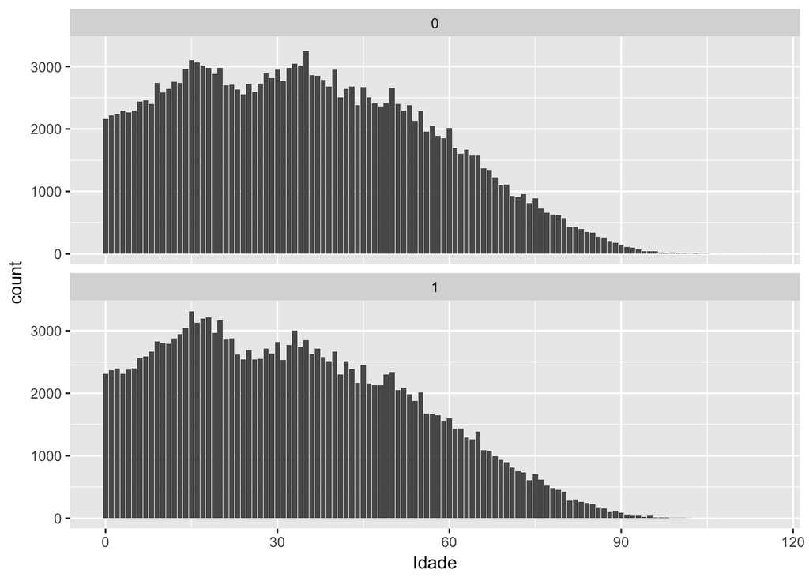

```r
ggplot(data=tabela.amostra.PNAD2015)+geom_bar(mapping=aes(x=Idade))+facet_wrap(~Sexo,nrow=2)
```

Notamos que após a idade 60, a contagem acima de 1000 é menor no gráfico inferior(que considera indivíduos do sexo masculino)

Com os resultados também vemos que salário é um coeficiente positivo. Ou seja, a tendência é que os salários sejam maiores para os homens em relação as mulheres. Para tal, vamos verificar a distribuição dos salários e qual sexo está.

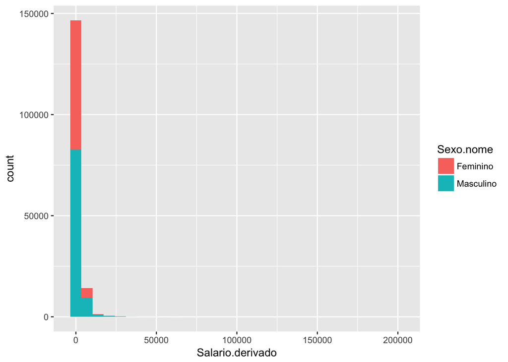

```r
ggplot(data=tabela.amostra.PNAD2015)+geom_histogram(mapping=aes(x=Salario.derivado,fill=Sexo.nome),na.rm = TRUE)
```

# Probit no R

Feitas as análises anteriores, agora rodamos um Probit, considerando o mesmo modelo anterior.

```
##
## Call:
## glm(formula = Sexo ~ Idade + Salario.derivado, family = binomial(link = "probit"),
##     data = tabela.amostra.PNAD2015)
##
## Deviance Residuals:
##    Min      1Q  Median      3Q     Max
## -6.560  -1.278   1.007   1.070   1.161
##
## Coefficients:
##                    Estimate Std. Error z value Pr(>|z|)
## (Intercept)       1.535e-01  9.636e-03  15.930  < 2e-16 ***
## Idade            -1.313e-03  2.317e-04  -5.668 1.45e-08 ***
## Salario.derivado  5.035e-05  1.522e-06  33.076  < 2e-16 ***
## ---
## Signif. codes:  0 '***' 0.001 '**' 0.01 '*' 0.05 '.' 0.1 ' ' 1
##
## (Dispersion parameter for binomial family taken to be 1)
##
##     Null deviance: 222412  on 162998  degrees of freedom
## Residual deviance: 220926  on 162996  degrees of freedom
##   (193905 observations deleted due to missingness)
## AIC: 220932
##
## Number of Fisher Scoring iterations: 5
```

O Probit corrobora os resultados do modelo Logit. Ou seja, as mulheres tendem a atingir maiores idades, portanto maiores expectativas de vida. Além disso, os salários tendem a ser menores para mulheres. O inverso vale para os homens.

# Exemplo de aplicativo em Shiny para a PNAD

Podemos criar um aplicativo em Shiny de forma a tornar os dados interativos para o usuário, bem como gerar gráficos e etc.

```r
shinyApp(
    ui = fluidPage(
      titlePanel("App PNAD :)"),
      mainPanel(
      #Output: Tabset w/ plot, summary, and table ----
      tabsetPanel(type = "tabs",
                  tabPanel("Gráfico", plotOutput("plot")),
                  tabPanel("Summary", verbatimTextOutput("summary")),
                  tabPanel("Head(Table)", dataTableOutput("table"))
                  )),
      downloadButton('downloadData', 'Download dados')),
    server = function(input, output) {
      output$plot <- renderPlot(ggplot(data=tabela.amostra.PNAD2015)+geom_bar(mapping = aes(x=UF)))
      output$summary <- renderPrint(summary(tabela.amostra.PNAD2015))
      output$table <- renderDataTable(tabela.amostra.PNAD2015)
      output$downloadData <- downloadHandler(
    filename = function() {
      paste("data-", Sys.Date(), ".csv", sep="")
    },
    content = function(file) {
      write.csv(data, file)
    }
  )
}

  )
```

Shiny applications not supported in static R Markdown documents